# Hôpital en tension HET

05/12/2014

## IoSlides - Diapo de titre

## Avertissement

Cette présentation est un essai du programme **ioslide**

To create an ioslides presentation from R Markdown:

- you specify the ioslides_presentation output format in the front-matter of your document.
- You can create a slide show broken up into sections by using the # and ## heading tags
- (you can also create a new slide without a header using a horizontal rule (—-).

Cette diapo sans titre a été crée avec la règle "—-"

## exemple de diapo

### avec un sous titre

## exemple de diapo

### avec un sous titre

On peut utiliser les raccourcis clavier pour modifier l'apparencede la présentation:

```
'f' enable fullscreen mode

'w' toggle widescreen mode

'o' enable overview mode

'h' enable code highlight mode

'p' show presenter notes
```

Appuyer sur Esc pour quitter tous ces modes.

Ce texte est centré.

This text is red

## Carte des tensions

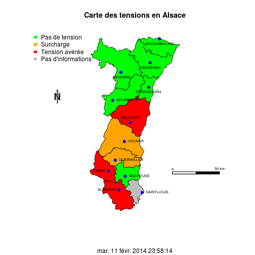

Cette présentation est basée sur le travail de la FEDORU (GT4 Hôpital en tension)

## Définition

L'HET est une situation exceptionnelle conséquence d'une inadéquation entre

- les moyens disponibles (lits, personnel)
- et les besoins immédiats d'hospitalisation non programmée.

C'est une situation critique pouvant évoluer ver une situation de crise.

Cette définition est proche de celle d'une situation de catastrophe (déséquilibre entre l'offre et la demande).

## Trois grandes classes de tensions

1. Tensions d'**affluence**
   - épidémique (grippe, bronchiolite)
   - saisonnière (marché de Noël) ou hebdomadaire (lundi)
2. Tensions par **défaut d'effectifs soignants** aux urgences
   - structurel (congés, mouvement social, effectifs insuffisants,…)
   - charge en soins (plusieurs patients en SAUV)
3. Tension par **carence en lit d'aval**
   - en hospitalisation conventionnelle
   - en soins critiques (Réa, SI, SC)
   - en psychiatrie (chambres d'isolement
   - en pédiatrie
   - en maternité

## Détection des situations de tension

## Les signalements par les professionnels des services de soins

**Seul le chef d'établissement peut déclencher le plan "hôpital en tension" (PHT)**.

- On appelle **"alerte tension"** ou "pré-tension" des situations de grandes difficultés générant des alertes "sauvages" vers l'ARS ou le SAMU
- Il est indispensable d'encadrer ces pratiques au niveau régional en assurant une rétro-information fiable entre direction des établissements, ARS et SAMU.
- RESURAL propose de créer un **outil en ligne** qui informe systématiquement
  - la direction de l'établissement
  - la plateforme de veille de l'ARS
  - les SAMU
  - les partenaires "utiles" (SDIS, Associations de PDS…)

La **traçabilité de ces alertes** et déclaration de tension représente une mine d'informations nécessaires pour conduire l'évaluation de l'action d'une région.

La centralisation et la formalisation des signalements constitue la première brique de **l'évaluation de l'action HET** d'un établissement ou d'une région.

## Exemple de formulaire

- Etablissement: liste déroulante
- Déclarant: identification
- Email déclarant:
- Téléphone d'astreinte du déclarant
- déclaré le: date/heure
- motif de l'alerte: texte libre (pas de lits disponible en médecine et en chirurgie. Accumulation de patients non hospitalisés pour manque de lits.)

Autorisation: médecin senior uniquement.

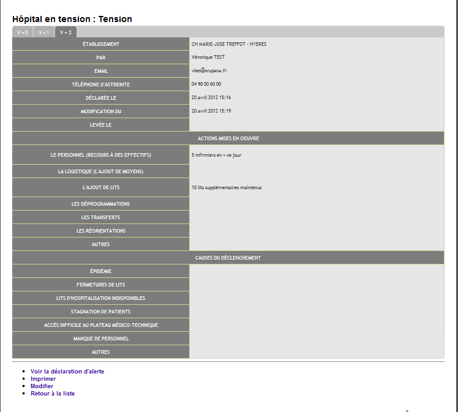

## Formulaire simplifié

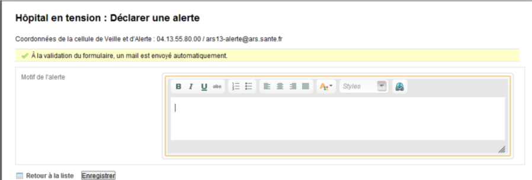

## Signalement par les directions d'établissement

Le signalement "alerte tension" ou "pre-tension" par le DG n'est pas un déclenchement officiel du PHET, mais un signal de réaction précoce qui suppose que la **cellule de veille** ou un professionnel de l'établissement aient déjà signalé une difficulté.

L'engagement du directeur est déjà une action qui le conduit: - à anticiper - à mettre en place les premières mesures - à tracer la démarche

## Signalement des situations épidémiques

- Mission spécifique de l'InVS qui vaut signal d'alerte.
- La connaissance de ces situations par la cellule de veille HET est un pré-requis indispensable.
- RESURAL souhaite mettre en place un système de relais de ces informations couplée avec des indicateurs d'HET.

## La FEDORU à identifié 39 indicateurs

que l'on peut répartir en cinq catégories [nombre d'indicateurs]:

- indicateurs **AMONT** (SAMU) [6]
- indicateurs activité des **URGENCES** [12]
- indicateurs **HOSPITALISATION A PARTIR DES URGENCES** [8]
- indicateurs **DISPONIBILITÉ** DES LITS D'AVAL__ [10]
- indicateurs **AVAL DES SERVICES DE COURT SÉJOUR** [3]

## Pour chaque indicateurs ont été défini:

- la **fréquence** de recueil idéale
- les indicateurs **proches**
- la nécessité ou non d'une **antériorité** (recueil sur du long terme)
- si une **automatisation** du recueil est possible
- la **complexité** du recueil
- si l'indicateur s'applique à la **détection ou au suivi** de la tension
- le **type de tension** pour lequel il est le plus adapté

## 1. Indicateur d'Amont

1.1 nombre de Dossier de régulation médicale (DRM) par 24h

1.2 nombre de DRM ouverts à un instant donné

1.3 nombre de DRM avec orientation vers un service d'urgence à un instant donné

1.4 nombre de SMUR engagés à un instant donné

1.5 nombre de VSAV régulés à un instant donné

1.6 alerte InVS - épidémie

## 2. Urgences

2.1 nombre de patient par médecin des urgences à un instant donné

2.2 nombre de passages sur les 24 dernières heures (RPU)

2.3 nombre de patients présents (TOP, RPU)

2.4 nombre de patients présents depuis plus de 6 heures

2.5 nombre de patients en attente de lits à un temps donné

2.6 nombre de patient en attente de prise en charge

## 2. Urgences (suite)

2.7 nombre de patients en UHCD

2.8 nombre de patients en attente de biologie ou d'imagerie

2.9 nombre de patients selon le code de gravité identifié au Tri IOA

2.10 Durée moyenne de présence aux urgences (RPU)

2.11 nombre de patients pris en charge par un médecin à un instant donné

2.12 NEDOCS

## 3. Hospitalisation à partir des urgences

3.1 Nombre de patients en attente de prise en charge dans un lit d'hospitalisation à un instant donné

3.2 Nombre de lits libérables.

3.3 Délai écoulé depuis la dernière admission en service de court séjour.

3.4 Temps d'attente moyen entre la décision d'admission et l'admission dans un service d'aval

3.5 Nombre de patients en attente d'un lit à un instant donné

3.6 Nombre de transfert par défaut de lit depuis 24 heures dont HAD

3.7 Nombre d'hospitalisations à partir des urgences

3.8 Nombre d'hospitalisations à partir des urgences à par unité d'aval.

## 4. Disponibilité des lits d'aval

4.1 Nombre de lits disponibles par service

4.2 Nombre d'admissions avant 12 heures

4.3 Nombre d'admission à horaire tardif

4.4 Nombre d'admissions programmées avec DMS cible

4.5 Nombre de journées non pertinentes (plus de 10j, plus de 30j)

4.6 Nombre de patients déprogrammés

4.7 DMS par service

4.8 Nombre de médecins présents pour chaque unité un jour donné

4.9 pourcentages de lits d'aval fermés dans l'établissement par rapport au au nombnre de lits d'aval de l'établissement

4.10 Nombre d'admissions programmées selon le jour de la semaine

## 5. Aval des services de court séjour

5.1 Nombre de demandes de places en SSR en cours

5.2 Nombre de patients hospitalisés en attente de place en EHPAD

5.3 Nombre de patients en soins critiques en attente de place en MCO ou autre un instant donné.

## Organiser la veille

## Au niveau des établissements

- La **cellule de veille** est une émanation de la commission des admissions et des soins non programmés.
- La fiche n°36 de la **circulaire relative à l'élaboration des plans blancs** en détaille la composition (DG, direction des soins, SU).
- En période de tension elle analyse un **tableau de bord** (à définir) quotidiennement.

-L'existence de cette cellule et sa réalité opérationnelle constituent en soi un **indicateur** mesurant l'implication de la structure dans le gestion des tensions.

- Idéalement la cellule rédige quotidiennement un **bilan de situation** qui est transmis au serveur régional de veille et d'alerte.

## Au niveau régional

- L'**ARS** organise la veille des indicateurs.
- Dans certaines régions cette veille est assurée en interne mais également **avec le concours de médecins urgentistes** qui assurent à tour de rôle une veille régionale des indicateurs, y compris durant les WE et JF.
- Un CR est établi quotidiennement à destination de l'ARS et des établissements.
- Cette politique proactive entraîne une multiplication des déclarations d'HET et la **mise en place d'actions correctrices** très précocement.

## Interpréter un indicateur

Pour interpréter un indicateur, il faut pouvoir disposer de seuils d'alerte. La définition de ces seuils repose sur:

- des recommandations d'experts
- la connaissance de mesures antérieures (comparaisons par antériorité).
- Il est donc nécessaire de constituer des bases de données stockant l'historique de ces mesures permettant de comparer les valeurs mesurées aux épisodes de tensions afin de définir la pertinence de l'indicateur.
- La création d'un cohorte de mesures ne saurait se limiter à quelques semaines dans l'année.
- Les chronologies des épisodes de tensions doivent faire l'objet d'un archivage détaillé et précis.

Ce n'est qu'à partir de là que l'on peut envisager une harmonisation des indicateurs (**Recommandation de la circulaire DHOS/CGR/2006/401 du 14/09/2006**).

## 4 niveaux chronologiques

- phase de **prévention** aux quotidien
- phase **réactive précoce**
- phase **réactive intermédiaire**
- phase réactive **pré-plan blanc**

## 7 catégories d'actions

1. **veiller** les indicateurs et les alertes (2)
2. contrôler l'**affluence** (7)
3. améliorer le **tri** des patients(2)
4. **réorienter** les patients ambulatoires vers d'autres modes de prise en charge (3)
5. repérer les **lits disponibles** plus facilement (10)
6. améliorer l'**accès aux lits** d'hospitalisation (29)
7. **adapter les moyens** à la demande (12)